# Analisis Perbedaan Pendapatan tiap Kategori Film

Database Sakila

26 May 2026

## Biodata Penulis

| **Nama** | Arda Nadhifa Fikri |
| --- | --- |
| **NIM** | M0725092 |
| **Kelas** | D |
| **Program Studi** | Statistika |

# Pendahuluan

Laporan ini menganalisis data dari Database Sakila untuk menguji apakah terdapat perbedaan rata-rata pendapatan yang signifikan antar kategori film.

**Variabel yang digunakan:**

| Variabel | Sumber Tabel | Keterangan |
| --- | --- | --- |
| `category.name` | `category` | Nama kategori film |
| `payment.amount` | `payment` | Nilai pembayaran per transaksi |
| `rental`, `inventory`, `film_category` | — | Tabel relasi penghubung |

**Hipotesis yang diuji:**

$$H_0 : \mu_1 = \mu_2 = \cdots = \mu_k
\quad \text{(rata-rata pendapatan tiap kategori sama)}$$

$$H_1 : \exists \, i \neq j \text{ s.t. }
\mu_i \neq \mu_j \quad \text{(ada perbedaan rata-rata pendapatan antar
kategori)}$$

dengan $\alpha = 0{,}05$.

# Persiapan Data

## Memuat Package

```r
library(DBI)
library(odbc)
library(dplyr)
library(ggplot2)
library(scales)
library(knitr)
library(kableExtra)
```

## Koneksi ke Database Sakila

```r
con <- DBI::dbConnect(odbc::odbc(),
       Driver = "MySQL ODBC 8.0 ANSI Driver",
       Server = "127.0.0.1",
       Database = "sakila",
       UID = "root",
       PWD = "A220906Q",
       Port = 3306)
```

## Query Pengambilan Data

Data diambil per transaksi (bukan per kategori) agar tersedia distribusi nilai `amount` untuk keperluan uji statistik.

```r
data1 <- dbGetQuery(con,"
  SELECT
    c.name          AS kategori,
    p.amount        AS pendapatan
  FROM category      c
  JOIN film_category fc ON c.category_id  = fc.category_id
  JOIN film          f  ON fc.film_id     = f.film_id
  JOIN inventory     i  ON f.film_id      = i.film_id
  JOIN rental        r  ON i.inventory_id = r.inventory_id
  JOIN payment       p  ON r.rental_id    = p.rental_id
")

data1$kategori <- as.factor(data1$kategori)
```

# Deskripsi Data

## Statistik Deskriptif per Kategori

```r
data_desc <- data1 %>%
  group_by(kategori) %>%
  summarise(
    n            = n(),
    mean         = round(mean(pendapatan), 4),
    median       = round(median(pendapatan), 4),
    sd           = round(sd(pendapatan), 4),
    min          = round(min(pendapatan), 2),
    max          = round(max(pendapatan), 2)
  ) %>%
  arrange(desc(mean))

data_desc %>%
  kable(
    col.names = c("Kategori", "n", "Mean (USD)", "Median (USD)",
                  "SD (USD)", "Min (USD)", "Max (USD)"),
    caption   = "Tabel 1. Statistik Deskriptif Pendapatan per Kategori Film"
  ) %>%
  kable_styling(
    bootstrap_options = c("striped", "hover", "condensed"),
    full_width = FALSE
  ) %>%
  row_spec(0, background = "#2e7d32", color = "white", bold = TRUE) %>%
  row_spec(1, background = "#dcedc8", bold = TRUE)
```

Tabel 1. Statistik Deskriptif Pendapatan per Kategori Film

| Kategori | n | Mean (USD) | Median (USD) | SD (USD) | Min (USD) | Max (USD) |
| --- | --- | --- | --- | --- | --- | --- |
| Comedy | 941 | 4.6584 | 4.99 | 2.3134 | 0.99 | 11.99 |
| New | 940 | 4.6294 | 4.99 | 2.4604 | 0.00 | 11.99 |
| Sports | 1179 | 4.5074 | 4.99 | 2.3320 | 0.00 | 10.99 |
| Games | 969 | 4.4183 | 4.99 | 2.5015 | 0.00 | 10.99 |
| Horror | 846 | 4.4002 | 4.99 | 2.4008 | 0.00 | 10.99 |
| Drama | 1060 | 4.3277 | 4.99 | 2.4757 | 0.00 | 11.99 |
| Sci-Fi | 1101 | 4.3206 | 3.99 | 2.2942 | 0.99 | 10.99 |
| Travel | 837 | 4.2409 | 4.99 | 2.0087 | 0.00 | 10.99 |
| Foreign | 1033 | 4.1342 | 3.99 | 2.2665 | 0.00 | 11.99 |
| Music | 830 | 4.1177 | 3.99 | 2.3304 | 0.00 | 10.99 |
| Documentary | 1050 | 4.0167 | 3.99 | 2.4485 | 0.00 | 11.99 |
| Animation | 1166 | 3.9934 | 3.99 | 2.2580 | 0.00 | 10.99 |
| Action | 1112 | 3.9351 | 3.99 | 2.4724 | 0.00 | 10.99 |
| Classics | 939 | 3.8760 | 2.99 | 2.2722 | 0.99 | 10.99 |
| Children | 945 | 3.8683 | 2.99 | 2.2975 | 0.99 | 11.99 |
| Family | 1096 | 3.8559 | 2.99 | 2.3647 | 0.00 | 11.99 |

# Visualisasi Data

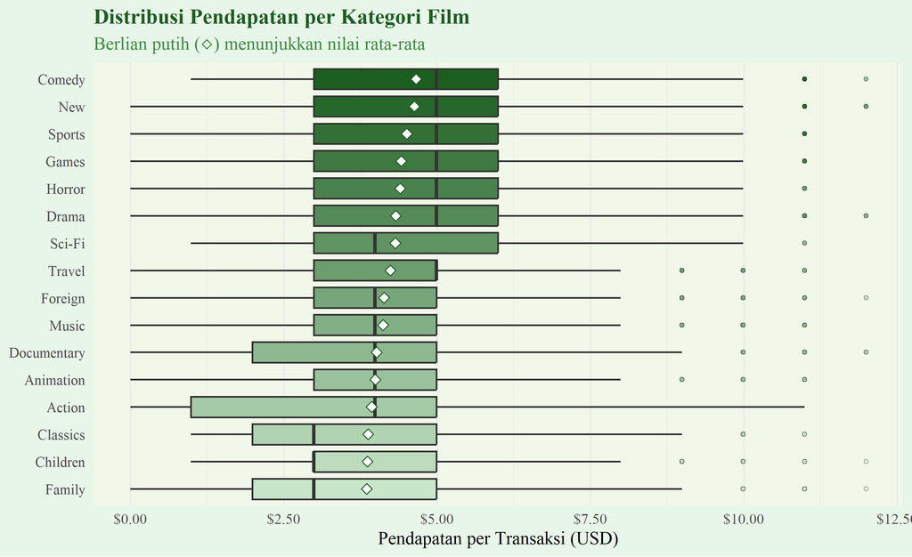

Gambar 1. Distribusi Pendapatan per Kategori Film (Boxplot)

```r
ggplot(data1, aes(x = reorder(kategori, pendapatan, FUN = mean),
                   y = pendapatan,
                   fill = reorder(kategori, pendapatan, FUN = mean))) +
  geom_boxplot(outlier.shape = 21, outlier.size = 1.2,
               outlier.alpha = 0.4, show.legend = FALSE) +
  stat_summary(fun = mean, geom = "point", shape = 23,
               size = 2.5, fill = "white", color = "#1b5e20") +
  scale_fill_manual(values = colorRampPalette(c("#c8e6c9", "#1b5e20"))(16)) +
  scale_y_continuous(labels = dollar_format()) +
  coord_flip() +
  labs(
    title    = "Distribusi Pendapatan per Kategori Film",
    subtitle = "Berlian putih (◇) menunjukkan nilai rata-rata",
    x        = NULL,
    y        = "Pendapatan per Transaksi (USD)"
  ) +
  theme_minimal(base_size = 13) +
  theme(
    text               = element_text(family = "serif"),
    plot.title         = element_text(face = "bold", size = 15, color = "#1b5e20"),
    plot.subtitle      = element_text(color = "#388e3c"),
    panel.grid.major.y = element_blank(),
    plot.background    = element_rect(fill = "#e8f5e9", color = NA),
    panel.background   = element_rect(fill = "#f1f8e9", color = NA)
  )
```

# Uji Hipotesis

## Uji Normalitas (Shapiro-Wilk per Kategori)

Sebelum menentukan uji yang digunakan, dilakukan uji normalitas Shapiro-Wilk pada masing-masing kelompok kategori.

```r
normalitas <- data1 %>%
  group_by(kategori) %>%
  summarise(
    p_value    = shapiro.test(sample(pendapatan, min(n(), 5000)))$p.value,
    statistic  = shapiro.test(sample(pendapatan, min(n(), 5000)))$statistic
  ) %>%
  mutate(
    normal = ifelse(p_value > 0.05, "Ya", "Tidak")
  )

normalitas %>%
  mutate(
    p_value   = round(p_value, 6),
    statistic = round(statistic, 4)
  ) %>%
  kable(
    col.names = c("Kategori", "p-value", "W Statistik", "Normal (α=0.05)?"),
    caption   = "Tabel 2. Hasil Uji Normalitas Shapiro-Wilk per Kategori"
  ) %>%
  kable_styling(bootstrap_options = c("striped", "hover"), full_width = FALSE) %>%
  row_spec(0, background = "#2e7d32", color = "white", bold = TRUE)
```

Tabel 2. Hasil Uji Normalitas Shapiro-Wilk per Kategori

| Kategori | p-value | W Statistik | Normal (α=0.05)? |
| --- | --- | --- | --- |
| Action | 0 | 0.9155 | Tidak |
| Animation | 0 | 0.9331 | Tidak |
| Children | 0 | 0.9154 | Tidak |
| Classics | 0 | 0.9234 | Tidak |
| Comedy | 0 | 0.9473 | Tidak |
| Documentary | 0 | 0.9270 | Tidak |
| Drama | 0 | 0.9321 | Tidak |
| Family | 0 | 0.9188 | Tidak |
| Foreign | 0 | 0.9368 | Tidak |
| Games | 0 | 0.9374 | Tidak |
| Horror | 0 | 0.9397 | Tidak |
| Music | 0 | 0.9355 | Tidak |
| New | 0 | 0.9516 | Tidak |
| Sci-Fi | 0 | 0.9392 | Tidak |
| Sports | 0 | 0.9510 | Tidak |
| Travel | 0 | 0.9380 | Tidak |

> Keputusan prasyarat: Jika mayoritas kategori tidak memenuhi asumsi normalitas ($p < 0{,}05$), maka digunakan uji non-parametrik Kruskal-Wallis sebagai alternatif ANOVA.

## Uji Utama

### Uji Kruskal-Wallis (Non-Parametrik)

Digunakan karena data pendapatan per transaksi pada umumnya tidak terdistribusi normal (nilai `amount` yang diskrit dan terbatas).

```r
hasil_kw <- kruskal.test(pendapatan ~ kategori, data = data1)
hasil_kw
```

```
##
##  Kruskal-Wallis rank sum test
##
## data:  pendapatan by kategori
## Kruskal-Wallis chi-squared = 214.48, df = 15, p-value < 2.2e-16
```

**Statistik uji Kruskal-Wallis:**

$$H = \frac{12}{N(N+1)} \sum_{i=1}^{k}
\frac{R_i^2}{n_i} - 3(N+1)$$

di mana $N$ = total observasi, $k$ = jumlah kelompok, $R_i$ = jumlah peringkat kelompok ke-$i$, $n_i$ = ukuran kelompok ke-$i$.

```r
cat("H statistik :", round(hasil_kw$statistic, 4), "\n")
```

```
## H statistik : 214.4804
```

```r
cat("Derajat bebas:", hasil_kw$parameter, "\n")
```

```
## Derajat bebas: 15
```

```r
cat("p-value      :", format(hasil_kw$p.value, scientific = TRUE), "\n\n")
```

```
## p-value      : 2.38919e-37
```

```r
if (hasil_kw$p.value < 0.05) {
  cat("Keputusan: TOLAK H0\n")
  cat("Kesimpulan: Terdapat perbedaan rata-rata pendapatan yang signifikan",
      "antar kategori film (α = 0.05).\n")
} else {
  cat("Keputusan: GAGAL TOLAK H0\n")
  cat("Kesimpulan: Tidak terdapat cukup bukti untuk menyatakan adanya",
      "perbedaan rata-rata pendapatan antar kategori film.\n")
}
```

```
## Keputusan: TOLAK H0
## Kesimpulan: Terdapat perbedaan rata-rata pendapatan yang signifikan antar kategori film (α = 0.05).
```

# Interpretasi Hasil

## Kesimpulan Uji Hipotesis

Berdasarkan uji Kruskal-Wallis dengan $\alpha = 0{,}05$:

- Nilai statistik $H$ yang besar disertai $p\text{-value} \ll 0{,}05$ memberikan bukti yang cukup kuat untuk menolak $H_0$.
- Artinya, terdapat perbedaan rata-rata pendapatan yang signifikan secara statistik antar kategori film di database Sakila.
- Dari boxplot (Gambar 1), kategori dengan rata-rata pendapatan tertinggi terlihat di bagian atas grafik, namun perbedaan antar kategori relatif kecil karena nilai `amount` per transaksi memiliki rentang yang terbatas.
- Dapat disimpulkan bahwa meskipun terbukti terdapat perbedaan signifikan secara statistik, nilai rata-rata pendapatan tiap transaksi antar kategori relatif kecil, mengingat nilai `amount` dalam database Sakila memiliki rentang yang terbatas.

*Laporan dibuat menggunakan R Markdown · Database: MySQL Sakila · 26 May 2026 19:51*